Synopsis

A data analysis was conducted to predict the method of exercise done from a set of features recorded from the exercise. A random forest learning algorithm using decision trees was conducted using the train function. The dataset was first prepared by removing variables with a near-zero variance.The dataset was then split into a training set and a validation set to benchmarkthe predictions from the training set against.Afterwards a correlation graph was utilized to determine a cutoff value in order to remove highly correlated variables from the training set. Lastly, the train function was ran and checked against a validation set using a confusion matrix.

Then, it helps to set the options

```r
options(scipen=100,digits=3)
```

```r
url<- "https://d396qusza40orc.cloudfront.net/predmachlearn/pml-training.csv"
download.file(url=url,destfile="pml-training.csv",method="curl")
pml<- read.csv("pml-training.csv")
pml2<- pml[,-c(1:7)]
```

After this, the features of the dataset are narrowed down. We remove the possible predictors with near-zero variance so that they do not have an undue influence on the model. Then, we look at how many missing values the remaining columns have. We see that there are only columns with 0 or 19,216 missing values. Since we cannot impute data when 98% of the column is missing, we remove the predictors that have more than 0 missing values.

```r
nearZero<- nearZeroVar(pml2)
pml3<- pml2[,-c(nearZero)]
is.na<- as.data.frame(colSums(is.na(pml3))) #only values are 0 and 19216
names(is.na)<- "missing_values"
missing<- count(is.na,vars="missing_values")
print(missing)
```

```
##   missing_values freq
## 1              0   53
## 2          19216   41
```

```r
pmlfull<- pml3[,colSums(is.na(pml3))==0]
```

```r
inTrain<- createDataPartition(y=pmlfull$classe,p=0.75,list=FALSE)
pmltr<-pmlfull[inTrain,]
pmlval<- pmlfull[-inTrain,]
```

In order to narrow the data set further for computational ease (so my 2012 Macbook Air can run the algorithms in a reasonable time,) we can remove highly correlated variables. To see what would be a good cutoff value for the correlation, a correlation heatmap was generated and a value was chosen that removes the variables in the correlation diagonal, which I appeared to be .75. The heatmap works best if the values are standardized before the correlation matrix is generated.

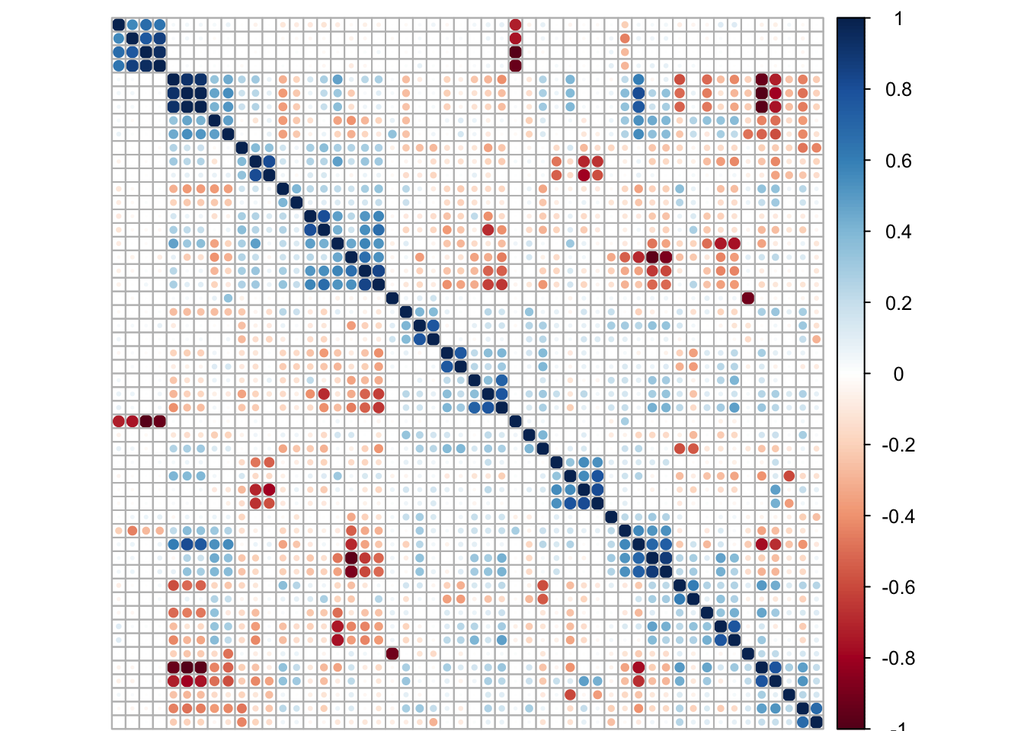

```r
pmltr2<- pmltr[,-53]
pmltr2<- scale(pmltr2,center=TRUE,scale=TRUE)
cor<- cor(pmltr2)
corrplot(cor,order="hclust",tl.pos="n")
```

```r
takeout<- findCorrelation(cor,cutoff=0.75)
```

From here, we create our final training set and validation set by removing the variables that correlated above 0.75

```r
pmltrfinal<- pmltr[,-takeout]
colstouse<- names(pmltrfinal)
pmlvalfinal<- pmlval[,colstouse]
```

```r
rftrain<- train(classe~.,data=pmltrfinal,method="rf",preProcess="pca",
                           trControl=rfControl)
rftrain
```

```
## Random Forest
##
## 14718 samples
##    31 predictor
##     5 classes: 'A', 'B', 'C', 'D', 'E'
##
## Pre-processing: principal component signal extraction, scaled, centered
## Resampling: Cross-Validated (10 fold, repeated 3 times)
##
## Summary of sample sizes: 13248, 13245, 13246, 13245, 13246, 13247, ...
##
## Resampling results across tuning parameters:
##
##   mtry  Accuracy  Kappa  Accuracy SD  Kappa SD
##    2    0.971     0.963  0.00427      0.00540
##   16    0.965     0.955  0.00452      0.00571
##   31    0.960     0.950  0.00459      0.00580
##
## Accuracy was used to select the optimal model using  the largest value.
## The final value used for the model was mtry = 2.
```

We can also see if the estimate is accurate by seeing if it can predict the validation set accurately. As we can see, the results are relatively close to the prediction made during training.

[output not shown]

Finally, we load the testing set, remove all of the columns that we did not use in our training set and make predictions:

```r
url2<- "https://d396qusza40orc.cloudfront.net/predmachlearn/pml-testing.csv"
download.file(url=url2,destfile="pml-testing.csv",method="curl")
pmltest<- read.csv("pml-testing.csv")
pmltest2<- pmltest[,-c(1:7)]
colstouse2<- colstouse[-32]
pmltestfinal<- pmltest2[,colstouse2]
predicts<- predict(rftrain,pmltestfinal)
```

Citations

Breiman,L. & Cutler, M. (2004). *Random Forests.* Retrieved from: https://www.stat.berkeley.edu/~breiman/RandomForests/cc_home.htm.

```r
warnings()
```